# 第 3 章 因子投资与资产定价异象

资产定价异象是**因子投资**的基础。本章有两个目标：

- 介绍简洁的思想和概念：基本因子模型，以及常见的经验证据（收益率和风险溢价的时变特征）；
- 为读者提供更深入的论文清单，以激发并满足进一步探索的兴趣。

本章并不试图完整覆盖因子投资相关的众多主题，而是希望给出一个宽视角的概览，抓住关键主题，并把读者引向相应的参考文献。因此，它可以看作一篇简短且非穷尽的文献综述。金融中的因子建模主题极其庞大，相关论文数量可观，并且仍在快速增长。

同行评审金融期刊大致可以分为两类。第一类是**学术期刊**。其中的文章多由教授撰写，读者也主要是学者；文章篇幅较长，且通常技术性较强。代表性期刊包括 *Journal of Finance*、*Review of Financial Studies* 和 *Journal of Financial Economics*。第二类更偏向**实务界**。这些论文较短，更容易阅读，主要面向金融从业者。两个典型例子是 *Journal of Portfolio Management* 和 *Financial Analysts Journal*。本章评述并提及的文章主要来自第一类期刊。

除学术论文外，已经有若干专著专门讨论风格配置这一主题（style allocation 是因子投资的同义说法，例如见理论文章 Barberis and Shleifer (2003)，以及实务文章 Asness et al. (2015)）。仅举几例：

- Ilmanen (2011)：对多个资产类别中的风险溢价作了详尽梳理，并提供了覆盖因子和时期的丰富描述性统计；
- Ang (2014)：讨论因子投资，重点放在资产管理行业；
- Bali, Engle, and Murray (2016)：一本关于信号横截面的完整著作，包含统计分析（单变量指标、相关性、持续性等）；
- Jurczenko (2017)：由领域专家对多个主题进行综述（因子纯度、可预测性、选择与加权、因子择时等）。

最后，我们还提及几篇视野较宽的相关论文：Goyal (2012)、Cazalet and Roncalli (2014) 以及 Baz et al. (2015)。

## 3.1 引言

因子投资虽然是一个已有数十年历史的学术主题，但随着股票交易型基金（ETF）作为投资载体的兴起而获得了更多关注。二者都在 2010 年代积累了显著动能。并不令人意外的是，实践中的金融工程与学术研究之间形成的反馈循环，以互利方式推动了双方发展。从业者依赖关键学术发现（例如资产定价异象），研究者则进一步深入更具实践意义的问题（例如因子暴露或交易成本）。近年来，研究者还尝试量化和界定因子指数对金融市场的影响。例如，Krkoska and Schenk-Hoppé (2019) 分析了羊群行为，而 Cong and Xu (2019) 表明，复合证券的引入会提高波动率和跨资产相关性。

因子模型的核心目标是理解**资产价格的驱动因素**。概括而言，因子投资背后的逻辑是：公司的金融表现取决于若干因子，这些因子可以是潜在且不可观测的，也可以与内在特征相关（例如会计比率）。正如 Cochrane (2011) 所说，第一个关键问题是：*哪些特征确实为平均收益率提供了独立信息？*回答这一问题有助于理解收益率横截面，也可能为收益率预测打开入口。

从理论上看，线性因子模型可被视为 Ross (1976) 的套利定价理论（APT）的特殊情形。该理论假设资产 $n$ 的收益率可以建模为若干基础因子 $f_k$ 的线性组合：

\begin{equation} \tag{3.1} r_{t,n}= \alpha_n+\sum_{k=1}^K\beta_{n,k}f_{t,k}+\epsilon_{t,n}, \end{equation}

其中，线性模型通常的计量约束成立：$\mathbb{E}[\epsilon_{t,n}]=0$、$\text{cov}(\epsilon_{t,n},\epsilon_{t,m})=0$ 对 $n\neq m$ 成立，并且 $\text{cov}(\textbf{f}_n,\boldsymbol{\epsilon}_n)=0$。如果市场因子之外的这些因子能够系统性解释平均收益率，Sharpe (1964)、Lintner (1965) 和 Mossin (1966) 提出的单因子资本资产定价模型（CAPM）就无法完整解释收益率的横截面差异。在 CAPM 中，市场组合是唯一的系统性风险因子；超出这一基准模型解释范围、具有稳定横截面收益差异的经验规律，通常称为资产定价“异象”。

自 Fama and French (1992) 与 Fama and French (1993) 两篇论文发表以来，资产定价异象的经验证据不断累积。这一开创性工作催生了一条繁荣的研究脉络，并已有相关元研究（例如 Green, Hand, and Zhang (2013)、Harvey, Liu, and Zhu (2016) 以及 McLean and Pontiff (2016)）。回归式 (3.1) 可以只估计一次（无条件），也可以在不同时间窗口上序贯估计。后一种情况下，参数（系数估计）会发生变化，因此模型被称为条件模型（关于该主题的近期结果以及相关研究的详细综述，可参见 Ang and Kristensen (2012) 与 Cooper and Maio (2019)）。条件模型更灵活，因为它们承认资产价格的驱动因素可能并非常数，而这似乎是一个合理的假设。

## 3.2 识别异象

### 3.2.1 挑战

显然，能否识别异象是关键一步，而这项任务的复杂性不容低估。由于学术发表偏向显著的正向结果（金融经济学中的例子见 Harvey (2017)），研究者容易选择性地报告结果，而后续研究有时会推翻这些结论。因此，复现研究十分必要；许多发现未能经受时间检验（Linnainmaa and Roberts (2018), Johannesson, Ohlson, and Zhai (2020)），考虑交易成本后尤其如此（Patton and Weller (2020), A. Y. Chen and Velikov (2020)）。不过，正如 Chen (2019) 所示，  
仅凭 $p$-hacking 并不能解释文献记录的全部异象。降低伪发现风险的一种方法是提高显著性门槛，通常是提高对 $t$ 统计量的要求，但相关争论仍在继续（Harvey, Liu, and Zhu (2016), A. Y. Chen (2020)）；另一种方法是采用多重检验（Harvey, Liu, and Saretto (2020), Vincent, Hsu, and Lin (2020)）。

一些研究者发现，异象会在发表后衰减：异象一旦公开，投资者便会据此交易，推高相关资产价格，直至异象消失。McLean and Pontiff (2016) 在美国市场记录了这一效应，但 Jacobs and Müller (2020) 发现，其他国家的因子收益在论文发表后依然持续。A. Y. Chen and Zimmermann (2020) 采用另一种方法，对收益率作发表偏差调整，并指出这一负向调整实际上相当小。Penasse (2019) 建议用 *alpha 衰减*来研究异象的持续或减弱。

因子溢价的消失可能源于羊群行为（Krkoska and Schenk-Hoppé (2019), Volpati et al. (2020)），也可能因所谓智能贝塔产品，尤其是 ETF 的普及而加快，因为这些产品让投资者能够直接配置价值、低波动等特定风格。关于因子投资吸引力的理论分析，可参见 Jin (2019)。另一方面，DeMiguel, Martin Utrera, and Uppal (2019) 认为，智能贝塔领域内拥挤交易造成的价格影响，会被领域外机构采用的多样化交易策略所缓解，例如高频交易者依据订单簿算法进行的交易。

本小节余下部分受到 Baker, Luo, and Taliaferro (2017) 以及 C. Harvey and Liu (2019) 的启发。

### 3.2.2 简单投资组合排序法

这是最常见的流程，也是 Fama and French (1992) 采用的方法。思路很简单。在某一日期，

1. 按照某个特定标准对公司排序（例如规模、市账率）；
2. 根据排序构造 $J\ge 2$ 个投资组合（即同质组），每组包含相同数量的股票（通常会构造 $J=2$、$J=3$、$J=5$ 或 $J=10$ 个组合，分别按该标准的中位数、三分位数、五分位数或十分位数切分）；
3. 组合内部股票的权重可以相等（等权），也可以与市值成比例；
4. 在未来某个日期（通常是一个月后）记录各组合收益率。随后重复这一流程，直到样本时间序列结束。

最终可得到每个分组 $j$ 的组合收益率时间序列 $r_t^j$。如果第一组（$j=1$）与最后一组（$j=J$）的 $t$ 检验表明平均收益率存在显著差异，就可识别出一个异象。更稳健的检验见 Cattaneo et al. (2020)。这种方法的一项重要局限在于，排序指标对收益率的影响可能并非单调，而只比较两个极端组合无法发现这种情况。Patton and Timmermann (2010) 与 Romano and Wolf (2013) 等研究讨论了这一问题。另一个隐患是，这些排序投资组合不仅可能捕捉与该特征有关的定价风险，还可能包含某些未定价风险。K. Daniel et al. (2020) 表明，可以将二者分离，并据此改进排序投资组合。

除了只关注一个标准，也可以按照更多特征对资产分组。Fama and French (1992) 的原始论文也将市值与账面市值比结合起来。每项特征分为 10 组，因此共形成 100 个投资组合。除数据可得性之外，排序过程中可纳入的特征数量没有上限。事实上，一些作者研究了更复杂的排序算法，以处理潜在的大量特征（例如 Feng, Polson, and Xu (2019) 以及 Bryzgalova, Pelger, and Zhu (2019)）。

最后，关于纳入资产收益率协方差结构的改进，可参见 Ledoit, Wolf, and Zhao (2020)；关于排序程序统计性质的理论研究，可参见 Cattaneo et al. (2020)（其中也包括与基于回归方法的理论联系）。值得注意的是，后者讨论了最优组合数量，并认为它很可能大于文献中常用的 10 个组合。

在下面的代码和图 3.1 中，我们计算规模组合（等权：市值高于中位数与低于中位数）。根据规模异象，市值低于中位数的公司平均而言应获得更高收益率。当图中的橙色柱高于蓝色柱时，这一点得到验证（大多数时候如此）。

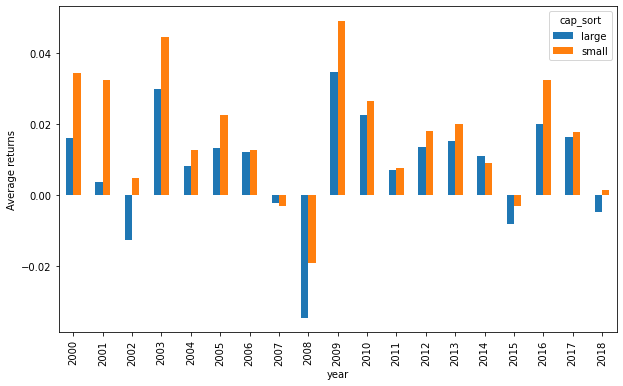

```python
df_median=[]          #creating empty placeholder for temporary dataframe
df=[]
df_median=data_ml[['date','Mkt_Cap_12M_Usd']].groupby(['date']).median().reset_index() # computing median
df_median.rename(columns = {'Mkt_Cap_12M_Usd': 'cap_median'}, inplace = True) # renaming for clarity
df = pd.merge(data_ml[["date",'Mkt_Cap_12M_Usd','R1M_Usd']],df_median,how='left', on=['date'])
df=df.groupby([pd.to_datetime(df['date']).dt.year,np.where(df['Mkt_Cap_12M_Usd'] > df['cap_median'], 'large', 'small')])['R1M_Usd'].mean().reset_index() # groupby and defining "year" and cap logic
df.rename(columns = {'level_1': 'cap_sort'}, inplace = True)
df.pivot(index='date',columns='cap_sort',values='R1M_Usd').plot.bar(figsize=(10,6))
plt.ylabel('Average returns')
plt.xlabel('year')
df_median=[]          #removing the temp dataframe to keep it light!
df=[]                 #removing the temp dataframe to keep it light!
```

图 3.1：规模因子：小公司与大公司的平均收益率。

### 3.2.3 因子

所谓因子的构造沿用上述思路。先按某项特征构建投资组合，再用特征一端的极端组合减去另一端的极端组合，形成多空因子：例如，规模因子是小公司组合减大公司组合，价值因子是高账面市值比组合减低账面市值比组合。具体构造有时更为细致，例如采用双变量排序并合并多个组合，Fama and French (1993) 的经典方法便是如此。下面列出最常见的因子及若干参考文献。关于各类因子的更完整讨论，可参阅本章开头列出的书籍。对大多数异象，文献都提出了基于风险或行为的理论解释。最常被引用的因子包括：

- 规模（**SMB** = 小公司减大公司）：Banz (1981), Fama and French (1992), Fama and French (1993), Van Dijk (2011), Asness et al. (2018) 以及 Astakhov, Havranek, and Novak (2019)。
- 价值（**HML** = 高减低：被低估公司减“成长型”公司）：Fama and French (1992), Fama and French (1993), C. S. Asness, Moskowitz, and Pedersen (2013)。
- 动量（**WML** = 赢家减输家）：Jegadeesh and Titman (1993), Carhart (1997) 以及 C. S. Asness, Moskowitz, and Pedersen (2013)。赢家是过去一年收益率最高的资产（有时收益率计算会截去最近一个月）。横截面动量与时间序列动量（趋势跟随）有关，但并不等同，见 Moskowitz, Ooi, and Pedersen (2012) 与 Lempérière et al. (2014)。动量也与不同频率上的反转运动相关（短期和长期反转），见 Luo, Subrahmanyam, and Titman (2020)。
- 盈利能力（**RMW** = 盈利稳健公司减盈利疲弱公司）：Fama and French (2015), Bouchaud et al. (2019)。在前一篇文献中，盈利能力定义为（收入 - 成本和费用）/权益。
- 投资（**CMA** = 保守减激进）：Fama and French (2015), Hou, Xue, and Zhang (2015)。投资以总资产增长额除以总资产来衡量。激进型公司是资产增长幅度最大的公司。
- 低“风险”（有时称为 **BAB**，即反贝塔策略）：Ang et al. (2006), Baker, Bradley, and Wurgler (2011), Frazzini and Pedersen (2014), Boloorforoosh et al. (2020), Baker, Hoeyer, and Wurgler (2020) 以及 Asness et al. (2020)。在这种情形下，各篇文章衡量风险的方式并不相同，包括简单波动率、市场贝塔和特质波动率等。

除低风险溢价这一显著例外之外，最主流的异象都由 Kenneth French 数据库维护并更新（https://mba.tuck.dartmouth.edu/pages/faculty/ken.french/data_library.html）。当然，因子的计算遵循一套特定规则，但这些规则在学术界通常被接受。另一个数据来源是 AQR 数据库：https://www.aqr.com/Insights/Datasets。

在本书使用的数据集中，我们并不使用账面市值比来代理价值异象，而是使用市净率（账面价值位于分母）。正如 Clifford Asness and Frazzini (2013) 所示，价值变量的选择会产生相当大的影响。

下面，我们从 Ken French 数据库导入数据。本章后续还会用到这些数据。

```python
import urllib.request

min_date = '1963-07-31'
max_date = '2020-03-28'
ff_url = "https://mba.tuck.dartmouth.edu/pages/faculty/ken.french/ftp/F-F_Research_Data_5_Factors_2x3_CSV.zip" # Create the download url
urllib.request.urlretrieve(ff_url,'factors.zip') # Download it and rename it
df_ff = pd.read_csv('F-F_Research_Data_5_Factors_2x3.csv', header=3, sep=',', quotechar='"')
df_ff.rename(columns = {'Mkt-RF':'MKT_RF'}, inplace = True) # renaming for clarity
df_ff[['MKT_RF','SMB','HML','RMW','CMA','RF']]=df_ff[['MKT_RF','SMB','HML','RMW','CMA','RF']]/100.0 # Scale returns
df_ff['year']=pd.to_datetime(df_ff['date']).dt.year
idx_ff=df_ff.index[(df_ff['date'] >= min_date) & (df_ff['date'] <= max_date)].tolist()
FF_factors=df_ff.iloc[idx_ff]
FF_factors=FF_factors.drop(columns=['date_int'])
FF_factors.iloc[1:6,1:7].head()
```

|  | MKT_RF | SMB | HML | RMW | CMA | RF |
| --- | --- | --- | --- | --- | --- | --- |
| 1 | 0.0507 | -0.0082 | 0.0182 | 0.0040 | -0.0040 | 0.0025 |
| 2 | -0.0157 | -0.0048 | 0.0017 | -0.0076 | 0.0024 | 0.0027 |
| 3 | 0.0253 | -0.0130 | -0.0004 | 0.0275 | -0.0224 | 0.0029 |
| 4 | -0.0085 | -0.0085 | 0.0170 | -0.0045 | 0.0222 | 0.0027 |
| 5 | 0.0183 | -0.0190 | -0.0006 | 0.0007 | -0.0030 | 0.0029 |

表 3.1：月度因子收益率样本。

在这些典型事实被发现之后，一些研究开始构建能够刻画这些性质的理论模型。下面列举若干例子：

- **规模**和**价值**：Berk, Green, and Naik (1999), K. D. Daniel, Hirshleifer, and Subrahmanyam (2001), Barberis and Shleifer (2003), Gomes, Kogan, and Zhang (2003), Carlson, Fisher, and Giammarino (2004), Arnott et al. (2014)；
- **动量**：Johnson (2002), Grinblatt and Han (2005), Vayanos and Woolley (2013), Choi and Kim (2014)。

此外，近期也有研究在基于风险的因子表示与行为理论之间建立桥梁。主要可参见 Barberis, Mukherjee, and Wang (2016) 以及 K. Daniel, Hirshleifer, and Sun (2020) 及其中引用的文献。

虽然这些因子（即多空组合）表现出时变风险溢价，并会被公司新闻和公告放大（Engelberg, McLean, and Pontiff (2018)），但它们在长周期中提供正收益这一点已有充分文献记录并被广泛接受。关于风险溢价估计程序及相应实证结果的技术细节，可参见 Gagliardini, Ossola, and Scaillet (2016)、综述 Gagliardini, Ossola, and Scaillet (2019) 以及相关文献。Ilmanen et al. (2019) 也进行了一项大样本研究，记录了因子溢价中的状态转换。此外，收益率可预测性本身也具有时变性（见 Farmer, Schmidt, and Timmermann (2019), Tsiakas, Li, and Zhang (2020) 以及 Liu, Pan, and Wang (2020)），并且估计方法仍可改进（Johnson (2019)）。

图 3.2 展示了五个常见因子按日历年聚合后的平均月收益率。无风险利率（严格来说并不是因子）最稳定，而市场因子（总市场收益率减无风险利率）波动最大。这是合理的，因为在这五个序列中，它是唯一的纯多头权益因子。

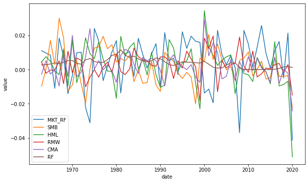

```python
FF_factors.groupby(FF_factors['year']).mean().plot(figsize=(10,6)) # groupby and defining "year" and cap logic
plt.ylabel('value')
plt.xlabel('date')
```

图 3.2：常见异象的平均收益率（1963-2020）。来源：Ken French 数据库。

投资者在配置特定因子时的个体属性是一个快速发展的研究主题。虽然它在一定程度上超出了本书范围，我们仍列出若干参考文献。Betermier, Calvet, and Sodini (2017) 表明，与处于最适合承担金融风险位置的成长型投资者相比，价值投资者年龄更大、更富有，并面临更低的收入风险。Cronqvist, Siegel, and Yu (2015) 的研究得出了不同结论：投资价值资产还是成长资产的倾向根植于遗传和人生经历（后者在 Cocco, Gomes, and Lopes (2020) 中得到确认，前者则在 Cronqvist et al. (2015) 的更一般背景下有进一步讨论）。心理特征也可以解释某些因子：当投资者进行外推时，他们很可能推动动量形成（该主题在 Barberis (2018) 中有完整综述）。这些偏好的微观和宏观经济后果见 Bhamra and Uppal (2019)。本段最后提到，也已有理论模型将投资者偏好和信念（通过前景理论）与市场异象联系起来（例如 Barberis, Jin, and Wang (2020)）。

最后，我们强调因子溢价可复现性的必要性，并呼应 Harvey (2020) 近期的社论。正如 Linnainmaa and Roberts (2018) 以及 Hou, Xue, and Zhang (2020) 所示，许多被宣称的因子实际上高度依赖数据；当投资范围改变或变量定义变化时，它们往往无法持续盈利（Clifford Asness and Frazzini (2013)）。

Campbell Harvey 及其合作者在 Harvey, Liu, and Zhu (2016)、C. Harvey and Liu (2019) 以及 Harvey and Liu (2019) 等一系列论文中，尝试系统梳理因子研究。这些工作强调，若要把某个异象称为“真实”因子，必须设置较高门槛。仅仅收紧 $p$ 值门槛并不能完全解决问题，因为数据窥探总能找出某种经过优化的策略：它在样本内可以产生大于 3，甚至大于 4 的 $t$ 统计量，却会在样本外失效。Harvey (2017) 建议采用贝叶斯方法，把数据所反映的显著性与先验信息结合为所谓贝叶斯化 *p* 值（见下文小节）。

沿着这一研究方向，学者继续探索“因子动物园”的丰富程度。Bryzgalova, Huang, and Julliard (2019) 提出一种计算上可行的大维因子模型贝叶斯估计方法，并评估 50 多个因子的所有可能组合，涉及数量极其庞大的系数。该方法结合贝叶斯化的 Fama and MacBeth (1973) 程序，可以区分普适性因子与冗余因子。Chordia, Goyal, and Saretto (2020) 模拟 200 万个交易策略来估计*伪发现*率，即错误识别出虚假因子的概率（I 型错误）。他们同样建议采用远高于 3 的 t 统计量门槛。类似地，Harvey and Liu (2020) 强调，*真实*异象有时也会因某次 $t$ 统计量过低而被遗漏（II 型错误）。

期刊倾向于发表正向结果，这促使研究者估计已报告收益率与*真实*收益率之间的差异。A. Y. Chen and Zimmermann (2020) 将这一差异称为*发表偏差*，并估计其大约为 12%。也就是说，如果一篇论文发表的平均收益率为 8%，实际值可能更接近 (1-12%)*8%=7%。从定性上看，这个 12% 的估计小于 McLean and Pontiff (2016) 中发现的样本外收益率下降幅度。

### 3.2.4 预测回归、排序与 p 值问题

为简化起见，我们假设如下简单形式：

\begin{equation} \tag{3.2} \textbf{r} = a+b\textbf{x}+\textbf{e}, \end{equation}

其中，向量 $\textbf{r}$ 汇集了所有股票的全部收益率，$\textbf{x}$ 是滞后变量，因此该回归具有预测性质。如果估计值 $\hat{b}$ 在给定门槛下显著，人们很容易据此断定 $\textbf{x}$ 能够很好地预测收益率，进而预期围绕 $\textbf{x}$ 极端值构建的多空组合会产生利润（方向取决于 $\hat{b}$ 的符号）。遗憾的是，这一结论往往并不成立，因为 $\hat{b}$ 只反映 $\textbf{x}$ 在过去预测收益率的能力，未来可能完全不同。

统计检验也用于投资组合排序法。假设两个极端组合的平均收益率预计存在很大差异，例如极小市值组合与极大市值组合，或表现最好的赢家组合与表现最差的输家组合。组合收益率记为 $r_t^+$ 和 $r_t^-$。最简单的均值检验为 $t=\sqrt{T}\frac{m_{r_+}-m_{r_-}}{\sigma_{r_+-r_-}}$，其中 $T$ 是样本点数量，$m_{r_\pm}$ 表示收益率均值，$\sigma_{r_+-r_-}$ 是两条序列之差的标准差，也就是多空组合的波动率。简言之，该统计量可以看作经过缩放的夏普比率，尽管夏普比率通常用于纯多头组合。随后还可据此计算 $p$ 值，以评估异象的稳健性。正如 Linnainmaa and Roberts (2018) 与 Hou, Xue, and Zhang (2020) 所示，研究者发现的许多因子都无法通过样本外检验。

人们容易对自己发现的异象过度乐观，其中一个原因是经常把 p 值反向解释。p 值常被误认为是在给定数据后，某项假设（例如“我的异象存在”）成立的概率。实际上方向恰好相反：它衡量的是在该假设成立的前提下，观察到当前数据样本的可能性。

\begin{align*} p-\text{value} &= P[D|H] \\ \text{target prob.}& = P[H|D]=\frac{P[D|H]}{P[D]}\times P[H], \end{align*}

其中 $H$ 表示假设，$D$ 表示数据。第二行的等式只是贝叶斯恒等式的直接应用：真正感兴趣的概率实际上是 $p$ 值的一个变换。

至少有两篇文章讨论了这一思想。Harvey (2017) 引入了**贝叶斯化** $p$ 值：

\begin{equation} \tag{3.3} \text{Bayesianized } p-\text{value}=\text{Bpv}= e^{-t^2/2}\times\frac{\text{prior}}{1+e^{-t^2/2}\times \text{prior}} , \end{equation}

其中，$t$ 是回归得到的 $t$ 统计量，也就是用于确定 p 值的统计量；公式中的 prior 表示分析者为假设（异象）成立所设定的先验赔率。其编码方式如下：假设原假设成立的先验概率为 p%（因此异象成立的先验概率为 (1-p)%），赔率写作 $p/(1-p)$。于是，当 t 统计量等于 2（大致对应 5% 的 p 值），先验赔率等于 6 时，Bpv 等于 $e^{-2}\times 6 \times(1+e^{-2}\times 6)^{-1}\approx 0.448$，即原假设为真的后验概率是 44.8%。这与原始 $p$ 值形成鲜明对比，因为后者不能解释为原假设成立的概率。当然，这种方法的缺点是结果高度依赖先验赔率的设定，而该设定完全由使用者指定。

Chinco, Neuhierl, and Weber (2020) 的研究路径很不相同，但同样涉及若干关键概念，例如在回归中引入参数的先验分布。他们表明，用 $L^2$ 约束限制预测回归（见第 5 章的岭回归），等价于对 $b$ 的真实分布加入先验判断。约束越强，估计值 $\hat{b}$ 就越会向零收缩。该研究的一项核心假设是，不同异象对应的真实 $b$ 共同服从某个以零为中心的高斯分布。关键参数是这一分布的标准差：标准差越大，显著异象出现的频率越高。值得注意的是，作者还表明该参数会随时间变化；更多细节请参阅原文。

### 3.2.5 Fama-MacBeth 回归

Fama and MacBeth (1973) 提出了另一种异象检验方法，即通过两阶段回归估计因子风险价格。第一阶段按股票逐一进行时间序列回归，估计前述关系并得到因子载荷 $\hat{\beta}_{i,k}$；随后将这些估计值代入第二阶段的横截面回归：

\begin{equation} r_{t,n}= \gamma_{t,0} + \sum_{k=1}^K\gamma_{t,k}\hat{\beta}_{n,k} + \varepsilon_{t,n}, \end{equation}

这些回归逐日在资产横截面上运行。6 理论上，贝塔应当已知，因此回归应使用 $\beta_{n,k}$，而不是其估计值。$\hat{\gamma}_{t,k}$ 是因子 $k$ 在时间 $t$ 的横截面风险价格估计值，其时间均值通常解释为该因子的平均风险溢价。若对  
$\varepsilon_{t,n}$ 作出适当的分布假设，就可以通过统计检验判断这些溢价是否显著。通常，检验时间聚合后的平均溢价 $\hat{\gamma}_k=\frac{1}{T}\sum_{t=1}^T\hat{\gamma}_{t,k}$ 所用的统计量为：

\begin{equation} t_k=\frac{\hat{\gamma}_k}{\hat{\sigma_k}/\sqrt{T}}$ \end{equation}

在纯高斯情形下，该统计量经常用于评估因子是否显著（$\hat{\sigma}_k$ 是 $\hat{\gamma}_{t,k}$ 的标准差）。

关于标准普通最小二乘（OLS）估计可能造成的偏误和精度损失，可参见 Jagannathan and Wang (1998) 以及 Petersen (2009) 的技术讨论。此外，第二阶段回归使用的 $\hat\beta_{i,k}$ 本身也是估计值，因此会引入第二层误差，即所谓的变量测量误差问题。相关扩展和解决方法可参见 Shanken (1992)、Ang, Liu, and Schwarz (2018) 以及 Jegadeesh et al. (2019)。

下面，我们在样本上执行 Fama and MacBeth (1973) 回归。先从第一阶段开始：逐只股票估计贝塔。下面构建一个专用函数来自动化该流程。

```python
import statsmodels.api as sm

data_FM = pd.merge(returns.iloc[:,0].reset_index(),FF_factors.iloc[:,0:7],how='left', on=['date'])
data=FF_factors
data_FM.dropna(inplace=True)
stocks_list=list(returns.columns)

results_params = []
reg_result=[]
df_res_full=[]
for i in range(len(returns.columns)):
    Y=returns.iloc[:,i].shift(-1).reset_index()
    Y=Y.drop(columns=['date'])
    Y.dropna(inplace=True)
    results=sm.OLS(endog=Y,exog=sm.add_constant(data_FM.iloc[0:227,2:7])).fit()
    results_params=results.params
    reg_result=pd.DataFrame(results_params)
    reg_result['stock_id']=stocks_list[i]
    df_res_full.append(reg_result)

df_res_full = pd.concat(df_res_full)
df_res_full.reset_index(inplace=True)
df_res_full.rename(columns={"index": "factors_name", 0: "betas"},inplace=True)
df_res_full_mat=df_res_full.pivot(index='stock_id',columns='factors_name',values='betas')
column_names_inverted = ["const", "MKT_RF", "SMB","HML","RMW","CMA"]
reg_result = df_res_full_mat.reindex(columns=column_names_inverted)
```

表 3.2：贝塔估计值样本（行号为股票 ID）。

```python
reg_result.head()
```

| factors_name stock_id | const | MKT_RF | SMB | HML | RMW | CMA |
| --- | --- | --- | --- | --- | --- | --- |
| 1 | 0.016794 | 0.163080 | 0.113891 | -0.501349 | 0.564917 | 0.625479 |
| 3 | 0.009116 | -0.221471 | -0.119134 | 0.047801 | -0.183690 | -0.266907 |
| 4 | 0.011704 | -0.001671 | -0.047076 | 0.001015 | -0.304841 | -0.006846 |
| 7 | 0.014391 | -0.345367 | -0.017726 | -0.012223 | -0.276708 | 0.218442 |
| 9 | 0.013088 | -0.196857 | 0.260565 | 0.139574 | -0.174628 | 0.084721 |

表中，MKT_RF 是市场收益率减无风险利率。相应系数通常称为贝塔，尤其是在单变量回归中。随后，我们将表 3.2 中的这些贝塔估计值重新整理，为第二阶段作准备。每一行对应一项资产：前 5 列是估计的因子载荷，其余列是资产收益率（逐日期）。

```python
returns_trsp=returns.transpose()
df_2nd_pass=pd.concat([reg_result.iloc[:,1:6], returns.transpose()], axis=1)
```

```python
df_2nd_pass.head()
```

| stock_id | MKT_RF | SMB | HML | RMW | CMA | 2000-01-31 | 2000-02-29 | 2000-03-31 | 2000-04-30 | 2000-05-31 | ... | 2018-03-31 | 2018-04-30 | 2018-05-31 | 2018-06-30 | 2018-07-31 | 2018-08-31 | 2018-09-30 | 2018-10-31 | 2018-11-30 | 2018-12-31 |
| --- | --- | --- | --- | --- | --- | --- | --- | --- | --- | --- | --- | --- | --- | --- | --- | --- | --- | --- | --- | --- | --- |
| 1 | 0.163080 | 0.113891 | -0.501349 | 0.564917 | 0.625479 | -0.036 | 0.263 | 0.031 | 0.448 | -0.097 | ... | 0.173 | -0.042 | -0.038 | 0.000 | -0.077 | -0.002 | -0.155 | 0.014 | -0.110 | 0.082 |
| 3 | -0.221471 | -0.119134 | 0.047801 | -0.183690 | -0.266907 | 0.077 | -0.024 | 0.018 | 0.027 | 0.050 | ... | -0.039 | 0.030 | -0.028 | -0.039 | 0.033 | -0.049 | -0.070 | 0.036 | -0.070 | 0.030 |
| 4 | -0.001671 | -0.047076 | 0.001015 | -0.304841 | -0.006846 | -0.016 | 0.000 | 0.153 | -0.011 | 0.014 | ... | 0.071 | -0.024 | 0.059 | 0.029 | -0.004 | 0.036 | -0.025 | 0.000 | -0.088 | 0.043 |
| 7 | -0.345367 | -0.017726 | -0.012223 | -0.276708 | 0.218442 | -0.009 | 0.027 | 0.000 | -0.017 | 0.018 | ... | 0.030 | 0.100 | 0.036 | -0.005 | 0.022 | -0.068 | -0.052 | 0.007 | -0.066 | 0.131 |
| 9 | -0.196857 | 0.260565 | 0.139574 | -0.174628 | 0.084721 | 0.032 | 0.076 | -0.025 | -0.022 | -0.121 | ... | 0.046 | 0.047 | 0.000 | 0.064 | -0.137 | -0.028 | -0.098 | -0.018 | -0.099 | 0.112 |

5 rows × 233 columns

表 3.3：重新整理后的贝塔估计值样本（可用于回归）。

```python
returns_trsp=returns.transpose()
df_2nd_pass=pd.concat([reg_result.iloc[:,1:6], returns.transpose()], axis=1)
betas=df_2nd_pass.iloc[:,0:5]
date_list=list(returns_trsp.columns)

results_params=[]
reg_result=[]
df_res_full=[]
for j in range(len(returns_trsp.columns)):
    Y=returns_trsp.iloc[:,j]
    results=sm.OLS(endog=Y,exog=sm.add_constant(betas)).fit()
    results_params=results.params
    reg_result_tmp=pd.DataFrame(results_params)
    reg_result_tmp['date']=date_list[j]
    df_res_full.append(reg_result_tmp)

df_res_full = pd.concat(df_res_full)
df_res_full.reset_index(inplace=True)
gammas=df_res_full

gammas.rename(columns={"index": "factors_name", 0: "betas"},inplace=True)
gammas_mat=gammas.pivot(index='date',columns='factors_name',values='betas')
column_names_inverted = ["const", "MKT_RF", "SMB","HML","RMW","CMA"]
gammas_mat = gammas_mat.reindex(columns=column_names_inverted)
gammas_mat.head()
```

| factors_name date | const | MKT_RF | SMB | HML | RMW | CMA |
| --- | --- | --- | --- | --- | --- | --- |
| 2000-01-31 | 0.016321 | -0.028149 | -0.005428 | 0.026040 | 0.078635 | 0.020799 |
| 2000-02-29 | 0.038006 | 0.006451 | 0.001304 | -0.051183 | -0.088695 | 0.043300 |
| 2000-03-31 | 0.014755 | 0.032022 | 0.056734 | -0.068795 | -0.103291 | -0.045641 |
| 2000-04-30 | 0.132511 | 0.199729 | -0.452970 | 0.281773 | 0.341264 | -0.023676 |
| 2000-05-31 | 0.012919 | -0.050791 | -0.064603 | 0.067470 | 0.110572 | 0.057169 |

表 3.4：gamma（溢价）值样本。

从图形上看，估计的溢价也非常波动。我们绘制市场、SMB 和 HML 因子的估计值。

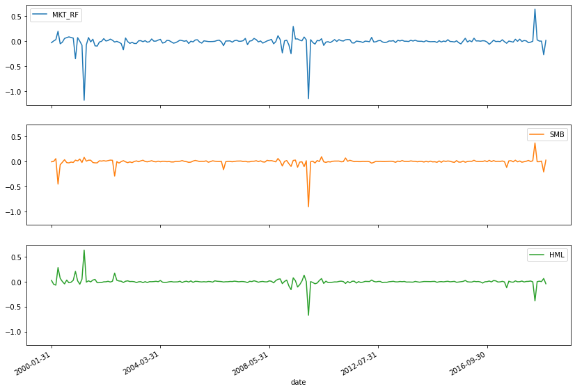

```python
gammas_mat.iloc[:,1:4].plot( figsize=(14,10), subplots=True, sharey=True, sharex=True)
plt.show()
```

图 3.3：Fama-MacBeth 回归中 gamma（溢价）的时间序列图。

样本末端的两个尖峰提示可能存在共线性问题：两个因子似乎相互抵消，合成效应难以解释。这凸显了惩罚化估计的价值（见第 5 章）。

### 3.2.6 因子竞争

因子的核心目的在于解释股票收益率横截面。无论从理论还是实践角度，都应尽量避免因子冗余。冗余会带来共线性，而共线性会干扰估计，这是一个众所周知的问题（Belsley, Kuh, and Welsch (2005)）。此外，资产管理人把收益表现分解为因子贡献时，因子之间若高度重叠，即绝对相关性很高，所得暴露就难以解释；正负暴露还可能相互抵消，造成误导。

识别冗余因子的一种简单方法，是依次将每个因子对其余所有因子作回归：

\begin{equation} \tag{3.4} f_{t,k} = a_k +\sum_{j\neq k} \delta_{k,j} f_{t,j} + \epsilon_{t,k}. \end{equation}

关键指标是 $a_k$ 估计值对应的检验统计量。如果 $a_k$ 显著不为零，说明其余因子无法完全解释因子 $k$ 的平均收益率。反之，如果截距不显著，该因子的收益率就可以由它对其他因子的暴露解释，因此可视为冗余因子。

Fama and French (2015) 给出了这一方法的一个典型应用：作者表明，在同时控制其他四个因子（Market、SMB、RMW 和 CMA）后，HML 因子是冗余的。下面使用更新后的样本复现其分析，数据直接取自 Kenneth French 维护的数据库。

按照式 (3.4) 运行回归，即可判断各因子是否冗余。

```python
import numpy as np
import statsmodels.api as sm

df_res_full=[]
for i in range(0,5):
    factors_list_full = ["MKT_RF", "SMB", "HML", "RMW", "CMA"]
    factors_list_tmp=factors_list_full
    Y=FF_factors[factors_list_full[i]]
    factors_list_tmp.remove(factors_list_full[i])
    data=FF_factors[factors_list_tmp]
    results=sm.OLS(endog=Y,exog=sm.add_constant(data)).fit()
    results_param=results.params
    reg_result_tmp=pd.DataFrame(results_param)
    reg_result_tmp['factor_mnemo']=Y.name
    reg_result_tmp['pvalue']=results.pvalues
    df_res_full.append(reg_result_tmp)

df_res_full = pd.concat(df_res_full)
df_res_full.reset_index(inplace=True)
df_res_full.rename(columns={0: "coeff"},inplace=True)
```

回归得到一个 $α$ 值向量。下面将这些数值与 $p$ 值门槛一同整理，并输出为汇总表。系数显著性按如下方式标记：*p* 值小于 0.001 标记为“***”，小于 0.01 标记为“**”，小于 0.05 标记为“*”。

```python
df_significance=df_res_full
conditions = [(df_significance['pvalue'] > 0) & (df_significance['pvalue'] < 0.001), # create a conditions' list
(df_significance['pvalue'] > 0.001) & (df_significance['pvalue'] < 0.01),
(df_significance['pvalue'] > 0.01) & (df_significance['pvalue'] < 0.05),
(df_significance['pvalue'] > 0.05)]

valuest = ['(***)','(**)','(*)','na'] # Values assign for each condition

# create a new column and use np.select to assign values to it using our lists as arguments
df_significance['significance'] = np.select(conditions, valuest).astype(str)
df_significance['coeff']=round(df_significance.coeff,3)
df_significance['coeff_stars']= df_significance.coeff.astype(str)+' '+df_significance.significance

# display updated DataFrame in the right shape
df_significance_pivot=df_significance.pivot(index='index',columns='factor_mnemo',values='coeff_stars').transpose()
df_significance_pivot= df_significance_pivot.reindex(columns=column_names_inverted)
df_significance_pivot.reindex(factors_list_full)
```

| index factor_mnemo | const | MKT_RF | SMB | HML | RMW | CMA |
| --- | --- | --- | --- | --- | --- | --- |
| MKT_RF | 0.008 (***) | NaN | 0.264 (***) | 0.101 na | -0.345 (***) | -0.903 (***) |
| SMB | 0.003 (*) | 0.134 (***) | NaN | 0.077 na | -0.428 (***) | -0.126 na |
| HML | -0.0 na | 0.027 na | 0.041 na | NaN | 0.151 (***) | 1.015 (***) |
| RMW | 0.004 (***) | -0.091 (***) | -0.222 (***) | 0.149 (***) | NaN | -0.278 (***) |

表 3.5：Fama and French (2015) 五因子之间的因子竞争。

我们确认，在资产定价模型中存在其他四个因子时，HML 因子仍然是冗余的。我们得到的数值与原始论文（Fama and French (2015)）中的结果非常接近，这很合理，因为我们只是在他们的初始样本上增加了 5 年数据。

在更宏观的层面上，研究者还试图判断：给定实际观测数据，以及计量经济学家为各候选模型设定的模型先验概率，哪些模型，也就是哪些因子组合，最有可能得到数据支持。例如，这一研究方向会量化 Fama and French (1993) 的三因子模型在多大程度上优于 Fama and French (2015) 的五因子模型。De Moor, Dhaene, and Sercu (2015) 为此提出一种新的 p 值计算方法，用于比较两个模型通过零 alpha 检验的相对可能性。更一般地，Chib, Zeng, and Zhao (2020) 随后改进了 Barillas and Shanken (2018) 的贝叶斯方法。

最后，近期研究对于最优因子数量的结论也存在分歧。传统文献聚焦于少数（3-5 个）因子，而 DeMiguel et al. (2020)、He, Huang, and Zhou (2020)、Kozak, Nagel, and Santosh (2019) 以及 Freyberger, Neuhierl, and Weber (2020) 等较新研究主张至少需要使用 15 个或更多因子（相反，Kelly, Pruitt, and Su (2019) 认为少量**潜在**因子可能已经足够）。Green, Hand, and Zhang (2017) 甚至发现，能够帮助解释收益率横截面的特征数量会随时间变化。

### 3.2.7 高级技术

因子数量持续增加，其在资产管理中的重要性也不断提升，这促使研究者设计更精细的方法来梳理所谓的“因子动物园”。更重要的是，这些方法还用于识别虚假异象，并比较不同的资产定价模型设定。下面列出其中几类。

- Feng, Giglio, and Xiu (2020) 将 LASSO 选择与 Fama-MacBeth 回归结合，用来检验新的因子模型是否值得采用。他们量化在一组预先定义的因子中加入一个新因子所带来的增益，并表明许多发表于 2010 年代论文中的因子并没有提供多少增量价值；
- C. Harvey and Liu (2019) 采用类似思路，对正交化因子使用 bootstrap。他们指出，预测变量之间的相关性是一个重大问题，而其方法正是为了处理这一问题。他们较长的程序旨在检验候选变量的最大额外贡献是否显著；
- Fama and French (2018) 通过最大夏普比率平方比较资产定价模型；
- Giglio and Xiu (2019) 使用基于主成分分析的三阶段方法估计因子风险溢价；
- Pukthuanthong, Roll, and Subrahmanyam (2018) 通过结合主成分分析与 Fama and MacBeth (1973) 回归，拆分已定价因子与未定价因子；
- Gospodinov, Kan, and Robotti (2019) 警示因子设定错误（即将虚假因子纳入回归变量列表）的风险。交易型因子（$resp$. 宏观经济因子）似乎更可能（$resp$. 更不可能）产生稳健识别（另见 Bryzgalova (2019)）。

显然，不存在万无一失的方法；这一领域研究之多，恰恰凸显了稳健性的重要性。依据因子直觉制定投资决策时，这一点尤其关键。短期策略面临的一项主要障碍，是因子表现很可能随时间变化。实践层面的结果可参见 Ang and Kristensen (2012) 以及 Cooper and Maio (2019)；偏理论的分析及其他实证结果可参见 Gagliardini, Ossola, and Scaillet (2016) 以及 S. Ma et al. (2020)。

## 3.3 因子还是特征？

用线性因子模型分解收益率很方便，因为解释直观。不过，学术文献一直在争论：公司收益率究竟由宏观经济因子暴露解释，还是仅由公司自身特征解释。早期研究 Lakonishok, Shleifer, and Vishny (1994) 认为，价值溢价可能源于投资者错误外推过去的盈利增长率；投资者对近期盈利能力较强的公司过度乐观。因此，未来收益率也可能由公司的核心会计特征驱动。问题由此变为：解释收益率时，究竟是公司特征更重要，还是宏观经济因子暴露更重要？

Daniel and Titman (1997) 的开创性研究为公司特征解释提供了证据，后续研究包括 K. Daniel, Titman, and Wei (2001) 以及 Daniel and Titman (2012)。他们表明，即使公司对 HML 或 SMB 因子的载荷为负，高账面市值比公司或小市值公司仍有更高的平均收益率。因此，真正起作用的似乎是公司内在特征，而不是因子暴露。关于特征在解释或预测收益率中的作用，还可参见以下研究：

- Goyal (2012) 第 2.5.2 节综述了 2010 年以前关于该主题的结果；
- Chordia, Goyal, and Shanken (2019) 发现，相比因子载荷，特征解释了估计预期收益率变动中更大的比例；
- Kozak, Nagel, and Santosh (2018) 将基于因子的溢价解释与一个理论模型相协调，在该模型中，部分投资者需求由情绪驱动；
- Han et al. (2019) 使用惩罚化回归表明，94 个特征中有 20 到 30 个有助于预测美国股票的月收益率。他们的方法很有意思：先用特征回归收益率并生成预测值，再用该预测值回归收益率，以评估预测是否可靠。后一项回归采用 LASSO 型惩罚（见第 5 章），从而把无用特征排除在模型之外。Rapach and Zhou (2019) 进一步将惩罚扩展到弹性网络（elastic net）。
- Kelly, Pruitt, and Su (2019) 与 Kim, Korajczyk, and Neuhierl (2019) 都估计了这样一类模型：因子是潜变量，而因子载荷（贝塔）以及可能的 alpha 取决于公司特征。Kirby (2020) 通过引入状态切换推广了第一种方法。相比之下，Lettau and Pelger (2020a) 与 Lettau and Pelger (2020b) 估计不与特定特征直接关联的潜在因子，并给出其方法的大样本渐近性质。
- 与 Hoechle, Schmid, and Zimmermann (2018) 类似，Gospodinov, Kan, and Robotti (2019) 以及 Bryzgalova (2019) 讨论了利用投资组合排序法生成多空收益率时可能出现的错误。作者表明，在某些情况下，基于这一流程的检验会产生误导；当排序特征与某个外部且不可观测的因子相关时，就会出现这种问题。他们提出一种新的回归方法来规避这一缺陷。

较新的另一支文献中，R. S. J. Koijen and Yogo (2019) 提出一个需求模型，投资者根据自己对特定公司特征的偏好构建投资组合。作者表明，该模型能够模拟大型机构投资者的持仓。在模型中，总需求以及由此形成的价格直接取决于特征，而非因子。后续研究 R. S. Koijen, Richmond, and Yogo (2019) 表明，少数几组特征足以预测未来收益率。作者还利用英国和美国的机构持仓数据发现，规模最大的投资者对价格形成最具影响力。类似地，Betermier, Calvet, and Jo (2019) 推导出一个简洁的一般均衡理论模型，能够生成规模、账面市值比等若干已有充分证据支持的异象。Arnott et al. (2014) 与 Alti and Titman (2019) 的模型也能在理论上生成已知异象。最后，在 I. Martin and Nagel (2019) 中，公司特征通过影响股息增长的可预测性来影响收益率。该论文讨论了一种渐近情形，其中资产数量与特征数量保持一定比例，并同时趋于无穷。

## 3.4 热点主题：动量、择时与 ESG

### 3.4.1 因子动量

鉴于因子动量确实具有盈利能力，H. Yang (2020b) 进一步考察其来源，并把股票因子动量组合分解为两个部分：因子择时组合和静态组合。前者试图利用因子收益率的序列相关获利，后者则用于获取因子溢价。作者发现，因子动量收益中较大的部分实际上由静态组合解释。同一作者在 H. Yang (2020a) 中提出一种新估计量，用于衡量因子动量的可预测性。Leippold and Yang (2021) 则给出了警示性讨论。

最后，Garcia, Medeiros, and Ribeiro (2021) 记录了日频因子动量。

基于从 Ken French 网站获得的数据，我们计算因子的自相关函数（ACF）。我们回顾：

\begin{equation} \text{ACF}_k(\textbf{x}_t)=\mathbb{E}[(\textbf{x}_t-\bar{\textbf{x}})(\textbf{x}_{t+k}-\bar{\textbf{x}})]. \end{equation}

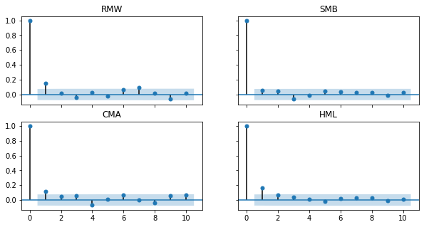

```python
import pandas as pd
import matplotlib.pyplot as plt
import statsmodels.api as sm

fig, ax = plt.subplots(2,2,figsize=(10,5),sharex='all', sharey='all') # how to
sm.graphics.tsa.plot_acf(FF_factors.RMW, lags=10, ax=ax[0,0],title='RMW') # chek fo rthe name
sm.graphics.tsa.plot_acf(FF_factors.CMA, lags=10, ax=ax[1,0],title='CMA')
sm.graphics.tsa.plot_acf(FF_factors.SMB, lags=10, ax=ax[0,1],title='SMB')
sm.graphics.tsa.plot_acf(FF_factors.HML, lags=10, ax=ax[1,1],title='HML')
plt.show()
```

图 3.4：常见因子组合的自相关图。

在选取的四个序列中，只有规模因子在一阶上没有显著自相关。

### 3.4.2 因子择时

鉴于因子溢价随时间变化的证据十分丰富，人们自然会问：能否预测某个因子何时表现较好或较差？关于择时有效性的证据并不一致：Greenwood and Hanson (2012)、Hodges et al. (2017)、Hasler, Khapko, and Marfe (2019)、Haddad, Kozak, and Santosh (2020) 以及 Lioui and Tarelli (2020) 得到正面结果；Asness et al. (2017) 得到负面结果；Dichtl et al. (2019) 的结果则正负参半。关于应使用哪些预测变量，也没有形成共识：Hodges et al. (2017) 使用一般宏观经济指标，Greenwood and Hanson (2012) 使用股票发行与回购数据，Dichtl et al. (2019) 使用总体基本面数据。Leippold and Rüegg (2020) 提出一种为纯多头组合构建合理择时策略的方法，同时把交易成本控制在可承受范围内。在基于机器学习的因子投资中，还可以把公司特定属性与大规模经济数据结合，以利用粒度更细的信息，详见第 4.7.2 节。

### 3.4.3 绿色因子

2010 年代，对伦理金融产品的需求急剧上升，推动了专注于社会责任投资（SRI，见 Camilleri (2020)）的基金创设。虽然这一现象并不算新（Schueth (2003), Hill et al. (2007)），但其加速发展促使研究者考察 ESG 标准（环境、社会、治理）相关特征是否被定价。已有数十篇甚至可能数百篇论文讨论这一问题，但尚未形成共识。越来越多的研究者关注气候变化的金融影响（见 Bernstein, Gustafson, and Lewis (2019), Hong, Li, and Xu (2019) 以及 Hong, Karolyi, and Scheinkman (2020)），以及社会对负责任公司行为的推动（Fabozzi (2020), Kurtz (2020)）。下面汇总一小组给出相互冲突结果的论文：

- **正面结果**：ESG 投资有效（Kempf and Osthoff (2007), Cheema-Fox et al. (2020)），可能有效（Nagy, Kassam, and Lee (2016), Alessandrini and Jondeau (2020)），或至少可以构造成有效策略（Branch and Cai (2012)）。一项大型元研究报告了压倒性的正面结果（Friede, Busch, and Bassen (2015)），但这也可能源于偏好正向结果的发表偏差。
- **负面结果**：Adler and Kritzman (2008) 以及 Blitz and Swinkels (2020) 认为，伦理投资并不能带来超额利润。按照 Lioui (2018) 的结论，一个可获利的 ESG 因子反而应做多不道德公司、做空道德公司。
- **混合结果**：ESG 投资可能在总体上有益，但在局部市场未必如此（Chakrabarti and Sen (2020)）。经过 ESG 筛选的组合并未显著跑赢未筛选组合，但波动率更低（Gibson et al. (2020), Gougler and Utz (2020)）。结果往往取决于具体定义，例如究竟采用 E、S 还是 G（Bruder et al. (2019)）。

除这些相互矛盾的结果外，若干文章还指出 ESG 度量具有复杂性。根据所选标准和数据供应商不同，结果可能发生巨大变化（见 Galema, Plantinga, and Scholtens (2008), Berg, Koelbel, and Rigobon (2020) 以及 Atta-Darkua et al. (2020)）。

本小节最后需要指出，ESG 标准也可以直接纳入机器学习模型，例如 Franco et al. (2020) 的做法。

## 3.5 与机器学习的联系

随着可用数据呈指数级增长，资产管理人自然希望利用公司层面的丰富属性来推断未来收益率。这些信息既包括会计比率等传统数据，也包括情绪等另类数据，而机器学习的目标正是完成这一任务。给定一大组预测变量（$\mathbf{X}$），目标是通过形如 (2.1) 的模型预测代表未来表现的某个代理变量 $\mathbf{y}$。

已有一些研究尝试这一方向（例如 Brandt, Santa-Clara, and Valkanov (2009), Hjalmarsson and Manchev (2012), Ammann, Coqueret, and Schade (2016), DeMiguel et al. (2020)），尽管其最初意图和重点并非机器学习。回头来看，这些方法确实与机器学习工具存在联系。一般形式如下：在时间  
$T$，投资者试图求解以下优化问题：

\begin{align*} \underset{\boldsymbol{\theta}_T}{\max} \ \mathbb{E}_T\left[ u(r_{p,T+1})\right] = \underset{\boldsymbol{\theta}_T}{\max} \ \mathbb{E}_T\left[ u\left(\left(\bar{\textbf{w}}_T+\textbf{x}_T\boldsymbol{\theta}_T\right)'\textbf{r}_{T+1}\right)\right] , \end{align*}

其中，$u$ 是某个效用函数，$r_{p,T+1}=\left(\bar{\textbf{w}}_T+\textbf{x}_T\boldsymbol{\theta}_T\right)'\textbf{r}_{T+1}$ 是投资组合收益率。组合权重由基准权重 $\bar{\textbf{w}}_T$ 与相对基准的偏离相加得到，而偏离项是特征的线性函数 $\textbf{x}_T\boldsymbol{\theta}_T$。上述优化问题还可能受到外部约束，例如杠杆限制。

实践中，向量 $\boldsymbol{\theta}_T$ 必须使用从 $T-\tau$ 到 $T-1$ 的历史数据估计。投资者求解如下问题：

\begin{align} \tag{3.5} \underset{\boldsymbol{\theta}_T}{\text{max}} \ \frac{1}{\tau} \sum_{t=T-\tau}^{T-1} u \left( \sum_{i=1}^{N_T}\left(\bar{w}_{i,t}+ \boldsymbol{\theta}'_T \textbf{x}_{i,t} \right)r_{i,t+1} \right) \end{align}

其中，样本大小为 $τ$，$N_T$ 是可投资范围内的资产数量。上述问题可以视为一项学习任务：选择参数，使奖励，也就是平均收益率最大化。

### 近期参考文献简表

独立于基于特征的方法，机器学习在金融中的应用已经蓬勃发展，起初只使用价格数据，后来逐渐将公司特征作为预测变量。下面按方法路径列举若干参考文献：

- 惩罚二次规划：Goto and Xu (2015), Ban, El Karoui, and Lim (2016) 以及 Perrin and Roncalli (2019)，
- 正则化预测回归：Rapach, Strauss, and Zhou (2013) 以及 Alexander Chinco, Clark-Joseph, and Ye (2019)，
- 支持向量机：Cao and Tay (2003)（以及其中引用的文献），
- 模型比较和/或聚合：Kim (2003), Huang, Nakamori, and Wang (2005), Matı́as and Reboredo (2012), Reboredo, Matı́as, and Garcia-Rubio (2012), Dunis et al. (2013), Gu, Kelly, and Xiu (2020b) 以及 Guida and Coqueret (2018b)。后两篇较新的文章使用了大量横截面特征。

第 6、7 和 16 章分别为基于树的方法、神经网络和强化学习技术提供更详细的文献清单。此外，关于分类器比较可参见 Ballings et al. (2015)，关于基于机器学习的预测技术综述可参见 Henrique, Sobreiro, and Kimura (2019) 以及 Bustos and Pomares-Quimbaya (2020)。

### 3.5.2 与资产定价模型的显式联系

因子投资与资产定价之间第一个也是最明显的联系，是（平均）收益率预测。主要的经典学术参考是 Gu, Kelly, and Xiu (2020b)。我们先写出一般方程，再对其进行说明：

\begin{equation} \tag{3.6} r_{t+1,n}=g(\textbf{x}_{t,n}) + \epsilon_{t+1}. \end{equation}

值得讨论的是，上述模型与式 (3.1) 有何不同。第一个明显区别是引入了非线性函数  
g ：除非出于简洁性和可解释性的考虑，并没有理由把模型限制为线性关系。Bansal and Viswanathan (1993) 是较早研究资产定价核中非线性关系的文献之一。

此外，模型允许载荷 $\boldsymbol{\beta}_{t,n}$ 随时间变化。接下来的关键是把公司特征引入上述方程。传统上，特征体现在因子的定义中，Fama and French (1993) 的经典定义便是如此。收益率按照公司对各因子的暴露进行分解，而这些因子又根据公司规模、会计比率和过去表现等信息构造。给定这些暴露后，股票表现便可归因于某种特定风格，例如小盘或价值风格。

通常，因子是依据阈值划分等简单规则构造的启发式投资组合。例如，可以把账面市值比低于 1/3 分位数的公司归为成长型公司，把高于 2/3 分位数的公司归为价值型公司，再用这两组股票构建等权多空组合来定义价值因子。需要注意的是，Fama and French (1993) 使用了更复杂的方法，在组合构成和权重设定中都考虑了市值。

机器学习带来的一项进展，是让因子构造实现自动化，Feng, Polson, and Xu (2019) 就采用了这种方法。作者不再依靠启发式规则定义因子，而是直接优化因子结构，使其尽可能拟合收益率横截面。优化由一个较深的前馈神经网络完成，并把特征滞后一期，以确保式 (3.6) 中的关系确实具有预测含义。理论上，这样得到的因子可以解释更大比例的样本内收益率方差；但模型是否真正具有预测能力，仍取决于其样本外泛化表现。

第三种方法来自 Kelly, Pruitt, and Su (2019)，尽管其统计处理本身并不属于机器学习。8 他们的思路恰好相反：因子是潜在且不可观测的，贝塔（因子载荷）则取决于公司特征。这为模型提供了很大的自由度，因为在 $r_{t,n}=\alpha_n+(\boldsymbol{\beta}_{t,n}(\textbf{x}_{t-1,n}))'\textbf{f}_t+\epsilon_{t,n},$ 中，只有特征 $\textbf{x}_{t-1,n}$ 已知，因子 $\textbf{f}_t$ 和函数形式 $\boldsymbol{\beta}_{t,n}(\cdot)$ 都需要估计。Kelly, Pruitt, and Su (2019) 使用线性形式，使这一问题更易处理。

最后，Gu, Kelly, and Xiu (2020a) 提出的第四种方法更进一步，把两种神经网络结构结合起来。第一个神经网络以特征 $\textbf{x}_{t-1}$ 为输入，生成因子载荷 $\boldsymbol{\beta}_{t-1}(\textbf{x}_{t-1})$；第二个网络则把收益率 $\textbf{r}_t$ 转换为因子值 $\textbf{f}_t(\textbf{r}_t)$（见 Feng, Polson, and Xu (2019)）。完整模型可写为：

\begin{equation} \tag{3.8} \textbf{r}_t=\boldsymbol{\beta}_{t-1}(\textbf{x}_{t-1})'\textbf{f}_t(\textbf{r}_t)+\boldsymbol{\epsilon}_t. \end{equation}

上述设定较为特殊，因为左端的输出同时也出现在右端，充当输入。机器学习中的自编码器（见第 7.6.2 节）也具有这一性质。它与主成分分析的目标类似，都是为数据集寻找简约表示；这里寻找的是收益率数据的非线性表示。在式 (3.8) 中，输入为 $\textbf{r}_t$，重构输出为 $\boldsymbol{\beta}_{t-1}(\textbf{x}_{t-1})'\textbf{f}_t(\textbf{r}_t)$。与一般回归模型一样，训练目标是尽量缩小二者之间的差异。

自编码器是一类让输出尽可能逼近输入、并以降维为目标的神经网络。Gu, Kelly, and Xiu (2020a) 的创新在于，把自编码器部分与用于建立载荷模型的普通感知机结合起来。完整网络结构如下。

$\left. \begin{array}{rl} \text{returns } (\textbf{r}_t) & \overset{NN_1}{\longrightarrow} \quad \text{ factors } (\textbf{f}_t=NN_1(\textbf{r}_t)) \\ \text{characteristics } (\textbf{x}_{t-1}) & \overset{NN_2}{\longrightarrow} \quad \text{ loadings } (\boldsymbol{\beta}_{t-1}=NN_2(\textbf{x}_{t-1})) \end{array} \right\} \longrightarrow \text{ returns } (r_t)$

一个简单自编码器只包含模型的第一行。第 7.6.2 节会更详细地讨论这一设定。

本章表明，资产定价与机器学习的交叉领域具有丰富多样的应用。相关文献已经十分庞杂，面对持续涌现的研究成果，往往很难区分噪声与真正有价值的思想。只有落实到实践和具体实现，才能判断哪些价值经得起炒作退潮后的检验。这一点尤其重要，因为市场参与者常常高估因子在现实投资者资产配置决策中的作用（见 Alex Chinco, Hartzmark, and Sussman (2019) 以及 Castaneda and Sabat (2019)）。

## 3.6 编程练习

1. 计算成长型组合与价值型组合的年度收益率。以市净率中位数为界划分公司并计算各组平均收益率（该变量在数据集中称为 `**Pb**’）。
2. 重复上述练习，但改为计算月度收益率，并绘制相应投资组合价值随时间变化的曲线。
3. 不再使用单一阈值，而是按市值四分位数构造简单排序投资组合。计算各组合的年度收益率并绘图。

## 参考文献

Adler, Timothy, and Mark Kritzman. 2008. “The Cost of Socially Responsible Investing.” Journal of Portfolio Management 35 (1): 52–56.

Alessandrini, Fabio, and Eric Jondeau. 2020. “Optimal Strategies for ESG Portfolios.” SSRN Working Paper 3578830.

Alti, Aydoğan, and Sheridan Titman. 2019. “A Dynamic Model of Characteristic-Based Return Predictability.” Journal of Finance 74 (6): 3187–3216.

Ammann, Manuel, Guillaume Coqueret, and Jan-Philip Schade. 2016. “Characteristics-Based Portfolio Choice with Leverage Constraints.” Journal of Banking & Finance 70: 23–37.

Ang, Andrew. 2014. Asset Management: A Systematic Approach to Factor Investing. Oxford University Press.

Ang, Andrew, Robert J Hodrick, Yuhang Xing, and Xiaoyan Zhang. 2006. “The Cross-Section of Volatility and Expected Returns.” Journal of Finance 61 (1): 259–99.

Ang, Andrew, and Dennis Kristensen. 2012. “Testing Conditional Factor Models.” Journal of Financial Economics 106 (1): 132–56.

Ang, Andrew, Jun Liu, and Krista Schwarz. 2018. “Using Individual Stocks or Portfolios in Tests of Factor Models.” SSRN Working Paper 1106463.

Arnott, Robert D, Mark Clements, Vitali Kalesnik, and Juhani T Linnainmaa. 2020. “Factor Momentum.” Journal of the American Statistical Association 3116974.

Asness, Cliff, Andrea Frazzini, Niels Joachim Gormsen, and Lasse Heje Pedersen. 2020. “Betting Against Correlation: Testing Theories of the Low-Risk Effect.” Journal of Financial Economics 135 (3): 629–52.

Asness, Clifford, Swati Chandra, Antti Ilmanen, and Ronen Israel. 2017. “Contrarian Factor Timing Is Deceptively Difficult.” Journal of Portfolio Management 43 (5): 72–87.

Asness, Clifford, and Andrea Frazzini. 2013. “The Devil in Hml’s Details.” Journal of Portfolio Management 39 (4): 49–68.

Asness, Clifford, Andrea Frazzini, Ronen Israel, Tobias J Moskowitz, and Lasse H Pedersen. 2018. “Size Matters, If You Control Your Junk.” Journal of Financial Economics 129 (3): 479–509.

Asness, Clifford, Antti Ilmanen, Ronen Israel, and Tobias Moskowitz. 2015. “Investing with Style.” Journal of Investment Management 13 (1): 27–63.

Asness, Clifford S, Tobias J Moskowitz, and Lasse Heje Pedersen. 2013. “Value and Momentum Everywhere.” Journal of Finance 68 (3): 929–85.

Astakhov, Anton, Tomas Havranek, and Jiri Novak. 2019. “Firm Size and Stock Returns: A Quantitative Survey.” Journal of Economic Surveys 33 (5): 1463–92.

Atta-Darkua, Vaska, David Chambers, Elroy Dimson, Zhenkai Ran, and Ting Yu. 2020. “Strategies for Responsible Investing: Emerging Academic Evidence.” Journal of Portfolio Management 46 (3): 26–35.

Back, Kerry. 2010. Asset Pricing and Portfolio Choice Theory. Oxford University Press.

Baker, Malcolm, Brendan Bradley, and Jeffrey Wurgler. 2011. “Benchmarks as Limits to Arbitrage: Understanding the Low-Volatility Anomaly.” Financial Analysts Journal 67 (1): 40–54.

Baker, Malcolm, Mathias F Hoeyer, and Jeffrey Wurgler. 2020. “Leverage and the Beta Anomaly.” Journal of Financial and Quantitative Analysis Forthcoming: 1–24.

Baker, Malcolm, Patrick Luo, and Ryan Taliaferro. 2017. “Detecting Anomalies: The Relevance and Power of Standard Asset Pricing Tests.”

Bali, Turan G, Robert F Engle, and Scott Murray. 2016. Empirical Asset Pricing: The Cross Section of Stock Returns. John Wiley & Sons.

Ballings, Michel, Dirk Van den Poel, Nathalie Hespeels, and Ruben Gryp. 2015. “Evaluating Multiple Classifiers for Stock Price Direction Prediction.” Expert Systems with Applications 42 (20): 7046–56.

Ban, Gah-Yi, Noureddine El Karoui, and Andrew EB Lim. 2016. “Machine Learning and Portfolio Optimization.” Management Science 64 (3): 1136–54.

Bansal, Ravi, and Salim Viswanathan. 1993. “No Arbitrage and Arbitrage Pricing: A New Approach.” Journal of Finance 48 (4): 1231–62.

Banz, Rolf W. 1981. “The Relationship Between Return and Market Value of Common Stocks.” Journal of Financial Economics 9 (1): 3–18.

Barberis, Nicholas. 2018. “Psychology-Based Models of Asset Prices and Trading Volume.” In Handbook of Behavioral Economics-Foundations and Applications.

Barberis, Nicholas, Lawrence J Jin, and Baolian Wang. 2020. “Prospect Theory and Stock Market Anomalies.” SSRN Working Paper 3477463.

Barberis, Nicholas, Abhiroop Mukherjee, and Baolian Wang. 2016. “Prospect Theory and Stock Returns: An Empirical Test.” Review of Financial Studies 29 (11): 3068–3107.

Barberis, Nicholas, and Andrei Shleifer. 2003. “Style Investing.” Journal of Financial Economics 68 (2): 161–99.

Barillas, Francisco, and Jay Shanken. 2018. “Comparing Asset Pricing Models.” Journal of Finance 73 (2): 715–54.

Baz, Jamil, Nicolas Granger, Campbell R Harvey, Nicolas Le Roux, and Sandy Rattray. 2015. “Dissecting Investment Strategies in the Cross Section and Time Series.” SSRN Working Paper 2695101.

Belsley, David A, Edwin Kuh, and Roy E Welsch. 2005. Regression Diagnostics: Identifying Influential Data and Sources of Collinearity. Vol. 571. John Wiley & Sons.

Berg, Florian, Julian F Koelbel, and Roberto Rigobon. 2020. “Aggregate Confusion: The Divergence of ESG Ratings.” SSRN Working Paper 3438533.

Berk, Jonathan B, Richard C Green, and Vasant Naik. 1999. “Optimal Investment, Growth Options, and Security Returns.” Journal of Finance 54 (5): 1553–1607.

Bernstein, Asaf, Matthew T Gustafson, and Ryan Lewis. 2019. “Disaster on the Horizon: The Price Effect of Sea Level Rise.” Journal of Financial Economics 134 (2): 253–72.

Betermier, Sebastien, Laurent E Calvet, and Evan Jo. 2019. “A Supply and Demand Approach to Equity Pricing.” SSRN Working Paper 3440147.

Betermier, Sebastien, Laurent E Calvet, and Paolo Sodini. 2017. “Who Are the Value and Growth Investors?” Journal of Finance 72 (1): 5–46.

Bhamra, Harjoat S, and Raman Uppal. 2019. “Does Household Finance Matter? Small Financial Errors with Large Social Costs.” American Economic Review 109 (3): 1116–54.

Blitz, David, and Laurens Swinkels. 2020. “Is Exclusion Effective?” Journal of Portfolio Management 46 (3): 42–48.

Boloorforoosh, Ali, Peter Christoffersen, Christian Gourieroux, and Mathieu Fournier. 2020. “Beta Risk in the Cross-Section of Equities.” Review of Financial Studies Forthcoming.

Bouchaud, Jean-philippe, Philipp Krueger, Augustin Landier, and David Thesmar. 2019. “Sticky Expectations and the Profitability Anomaly.” Journal of Finance 74 (2): 639–74.

Branch, Ben, and Li Cai. 2012. “Do Socially Responsible Index Investors Incur an Opportunity Cost?” Financial Review 47 (3): 617–30.

Brandt, Michael W, Pedro Santa-Clara, and Rossen Valkanov. 2009. “Parametric Portfolio Policies: Exploiting Characteristics in the Cross-Section of Equity Returns.” Review of Financial Studies 22 (9): 3411–47.

Bruder, Benjamin, Yazid Cheikh, Florent Deixonne, and Ban Zheng. 2019. “Integration of ESG in Asset Allocation.” SSRN Working Paper 3473874.

Bryzgalova, Svetlana. 2019. “Spurious Factors in Linear Asset Pricing Models.”

Bryzgalova, Svetlana, Jiantao Huang, and Christian Julliard. 2019. “Bayesian Solutions for the Factor Zoo: We Just Ran Two Quadrillion Models.” SSRN Working Paper 3481736.

Bryzgalova, Svetlana, Markus Pelger, and Jason Zhu. 2019. “Forest Through the Trees: Building Cross-Sections of Stock Returns.” SSRN Working Paper 3493458.

Bustos, O, and A Pomares-Quimbaya. 2020. “Stock Market Movement Forecast: A Systematic Review.” Expert Systems with Applications Forthcoming.

Camilleri, Mark Anthony. 2020. “The Market for Socially Responsible Investing: A Review of the Developments.” Social Responsibility Journal Forthcoming.

Cao, Li-Juan, and Francis Eng Hock Tay. 2003. “Support Vector Machine with Adaptive Parameters in Financial Time Series Forecasting.” IEEE Transactions on Neural Networks 14 (6): 1506–18.

Carhart, Mark M. 1997. “On Persistence in Mutual Fund Performance.” Journal of Finance 52 (1): 57–82.

Carlson, Murray, Adlai Fisher, and Ron Giammarino. 2004. “Corporate Investment and Asset Price Dynamics: Implications for the Cross-Section of Returns.” Journal of Finance 59 (6): 2577–2603.

Castaneda, Pablo, and Jorge Sabat. 2019. “Microfounding the Fama-Macbeth Regression.” SSRN Working Paper 3435141.

Cattaneo, Matias D, Richard K Crump, Max Farrell, and Ernst Schaumburg. 2020. “Characteristic-Sorted Portfolios: Estimation and Inference” Forthcoming: 1–47.

Cazalet, Zélia, and Thierry Roncalli. 2014. “Facts and Fantasies About Factor Investing.” SSRN Working Paper 2524547.

Chakrabarti, Gagari, and Chitrakalpa Sen. 2020. “Time Series Momentum Trading in Green Stocks.” Studies in Economics and Finance.

Cheema-Fox, Alexander, Bridget Realmuto LaPerla, George Serafeim, David Turkington, and Hui Stacie Wang. 2020. “Decarbonization Factors.” SSRN Working Paper 3448637.

Chen, Andrew Y. 2019. “The Limits of P-Hacking: A Thought Experiment.” SSRN Working Paper 3272572.

Chen, Andrew Y. 2020. “Do T-Stat Hurdles Need to Be Raised?” SSRN Working Paper 3254995.

Chen, Andrew Y, and Mihail Velikov. 2020. “Zeroing in on the Expected Returns of Anomalies.” SSRN Working Paper 3073681.

Chen, Andrew Y, and Tom Zimmermann. 2020. “Publication Bias and the Cross-Section of Stock Returns.” Review of Asset Pricing Studies Forthcoming.

Chen, Luyang, Markus Pelger, and Jason Zhu. 2020. “Deep Learning in Asset Pricing.” SSRN Working Paper 3350138.

Chib, Siddhartha, Xiaming Zeng, and Lingxiao Zhao. 2020. “On Comparing Asset Pricing Models.” Journal of Finance 75 (1): 551–77.

Chinco, Alexander, Adam D Clark-Joseph, and Mao Ye. 2019. “Sparse Signals in the Cross-Section of Returns.” Journal of Finance 74 (1): 449–92.

Chinco, Alexander, Andreas Neuhierl, and Michael Weber. 2020. “Estimating the Anomaly Baserate.” Journal of Financial Economics Forthcoming.

Chinco, Alex, Samuel M Hartzmark, and Abigail B Sussman. 2019. “Necessary Evidence for a Risk Factor’s Relevance.” SSRN Working Paper 3487624.

Choi, Seung Mo, and Hwagyun Kim. 2014. “Momentum Effect as Part of a Market Equilibrium.” Journal of Financial and Quantitative Analysis 49 (1): 107–30.

Chordia, Tarun, Amit Goyal, and Alessio Saretto. 2020. “Anomalies and False Rejections.” Review of Financial Studies 33 (5): 2134–79.

Chordia, Tarun, Amit Goyal, and Jay Shanken. 2019. “Cross-Sectional Asset Pricing with Individual Stocks: Betas Versus Characteristics.” SSRN Working Paper 2549578.

Cocco, Joao F, Francisco Gomes, and Paula Lopes. 2020. “Evidence on Expectations of Household Finances.” SSRN Working Paper 3362495.

Cochrane, John H. 2009. Asset Pricing: Revised Edition. Princeton University Press.

Cochrane, John H. 2011. “Presidential Address: Discount Rates.” Journal of Finance 66 (4): 1047–1108.

Cong, Lin William, and Douglas Xu. 2019. “Rise of Factor Investing: Asset Prices, Informational Efficiency, and Security Design.” SSRN Working Paper 2800590.

Cooper, Ilan, and Paulo F Maio. 2019. “New Evidence on Conditional Factor Models.” Journal of Financial and Quantitative Analysis 54 (5): 1975–2016.

Cronqvist, Henrik, Alessandro Previtero, Stephan Siegel, and Roderick E White. 2015. “The Fetal Origins Hypothesis in Finance: Prenatal Environment, the Gender Gap, and Investor Behavior.” Review of Financial Studies 29 (3): 739–86.

Cronqvist, Henrik, Stephan Siegel, and Frank Yu. 2015. “Value Versus Growth Investing: Why Do Different Investors Have Different Styles?” Journal of Financial Economics 117 (2): 333–49.

Daniel, Kent D, David Hirshleifer, and Avanidhar Subrahmanyam. 2001. “Overconfidence, Arbitrage, and Equilibrium Asset Pricing.” Journal of Finance 56 (3): 921–65.

Daniel, Kent, David Hirshleifer, and Lin Sun. 2020. “Short and Long Horizon Behavioral Factors.” Review of Financial Studies 33 (4): 1673–1736.

Daniel, Kent, Lira Mota, Simon Rottke, and Tano Santos. 2020. “The Cross-Section of Risk and Return.” Review of Financial Studies 33 (5): 1927–79.

Daniel, Kent, and Sheridan Titman. 1997. “Evidence on the Characteristics of Cross Sectional Variation in Stock Returns.” Journal of Finance 52 (1): 1–33.

Daniel, Kent, and Sheridan Titman. 2012. “Testing Factor-Model Explanations of Market Anomalies.” Critical Finance Review 1 (1): 103–39.

Daniel, Kent, Sheridan Titman, and KC John Wei. 2001. “Explaining the Cross-Section of Stock Returns in Japan: Factors or Characteristics?” Journal of Finance 56 (2): 743–66.

DeMiguel, Victor, Alberto Martin Utrera, and Raman Uppal. 2019. “What Alleviates Crowding in Factor Investing?” SSRN Working Paper 3392875.

DeMiguel, Victor, Alberto Martin Utrera, Raman Uppal, and Francisco J Nogales. 2020. “A Transaction-Cost Perspective on the Multitude of Firm Characteristics.” Review of Financial Studies 33 (5): 2180–2222.

De Moor, Lieven, Geert Dhaene, and Piet Sercu. 2015. “On Comparing Zero-Alpha Tests Across Multifactor Asset Pricing Models.” Journal of Banking & Finance 61: S235–S240.

Dichtl, Hubert, Wolfgang Drobetz, Harald Lohre, Carsten Rother, and Patrick Vosskamp. 2019. “Optimal Timing and Tilting of Equity Factors.” Financial Analysts Journal 75 (4): 84–102.

Dunis, Christian L, Spiros D Likothanassis, Andreas S Karathanasopoulos, Georgios S Sermpinis, and Konstantinos A Theofilatos. 2013. “A Hybrid Genetic Algorithm–Support Vector Machine Approach in the Task of Forecasting and Trading.” Journal of Asset Management 14 (1): 52–71.

Ehsani, Sina, and Juhani T Linnainmaa. 2019. “Factor Momentum and the Momentum Factor.” SSRN Working Paper 3014521.

Engelberg, Joseph, R David McLean, and Jeffrey Pontiff. 2018. “Anomalies and News.” Journal of Finance 73 (5): 1971–2001.

Fabozzi, Frank J. 2020. “Introduction: Special Issue on Ethical Investing.” Journal of Portfolio Management 46 (3): 1–4.

Falck, Antoine, Adam Rej, and David Thesmar. 2020. “Is Factor Momentum More Than Stock Momentum?” arXiv Preprint, no. 2009.04824.

Fama, Eugene F, and Kenneth R French. 1992. “The Cross-Section of Expected Stock Returns.” Journal of Finance 47 (2): 427–65.

Fama, Eugene F, and Kenneth R French. 1993. “Common Risk Factors in the Returns on Stocks and Bonds.” Journal of Financial Economics 33 (1): 3–56.

Fama, Eugene F, and Kenneth R French. 2015. “A Five-Factor Asset Pricing Model.” Journal of Financial Economics 116 (1): 1–22.

Fama, Eugene F, and Kenneth R French. 2018. “Choosing Factors.” Journal of Financial Economics 128 (2): 234–52.

Fama, Eugene F, and James D MacBeth. 1973. “Risk, Return, and Equilibrium: Empirical Tests.” Journal of Political Economy 81 (3): 607–36.

Farmer, Leland, Lawrence Schmidt, and Allan Timmermann. 2019. “Pockets of Predictability.” SSRN Working Paper 3152386.

Feng, Guanhao, Stefano Giglio, and Dacheng Xiu. 2020. “Taming the Factor Zoo: A Test of New Factors.” Journal of Finance 75 (3): 1327–70.

Feng, Guanhao, Nicholas G Polson, and Jianeng Xu. 2019. “Deep Learning in Characteristics-Sorted Factor Models.” SSRN Working Paper 3243683.

Franco, Carmine de, Christophe Geissler, Vincent Margot, and Bruno Monnier. 2020. “ESG Investments: Filtering Versus Machine Learning Approaches.” arXiv Preprint, no. 2002.07477.

Frazzini, Andrea, and Lasse Heje Pedersen. 2014. “Betting Against Beta.” Journal of Financial Economics 111 (1): 1–25.

Freyberger, Joachim, Andreas Neuhierl, and Michael Weber. 2020. “Dissecting Characteristics Nonparametrically.” Review of Financial Studies 33 (5): 2326–77.

Friede, Gunnar, Timo Busch, and Alexander Bassen. 2015. “ESG and Financial Performance: Aggregated Evidence from More Than 2000 Empirical Studies.” Journal of Sustainable Finance & Investment 5 (4): 210–33.

Gagliardini, Patrick, Elisa Ossola, and Olivier Scaillet. 2016. “Time-Varying Risk Premium in Large Cross-Sectional Equity Data Sets.” Econometrica 84 (3): 985–1046.

Gagliardini, Patrick, Elisa Ossola, and Olivier Scaillet. 2019. “Estimation of Large Dimensional Conditional Factor Models in Finance.” SSRN Working Paper 3443426.

Galema, Rients, Auke Plantinga, and Bert Scholtens. 2008. “The Stocks at Stake: Return and Risk in Socially Responsible Investment.” Journal of Banking & Finance 32 (12): 2646–54.

Gibson, Rajna, Simon Glossner, Philipp Krueger, Pedro Matos, and Tom Steffen. 2020. “Responsible Institutional Investing Around the World.” SSRN Working Paper 3525530.

Giglio, Stefano, and Dacheng Xiu. 2019. “Asset Pricing with Omitted Factors.” SSRN Working Paper 2865922.

Gomes, Joao, Leonid Kogan, and Lu Zhang. 2003. “Equilibrium Cross Section of Returns.” Journal of Political Economy 111 (4): 693–732.

Gospodinov, Nikolay, Raymond Kan, and Cesare Robotti. 2019. “Too Good to Be True? Fallacies in Evaluating Risk Factor Models.” Journal of Financial Economics 132 (2): 451–71.

Goto, Shingo, and Yan Xu. 2015. “Improving Mean Variance Optimization Through Sparse Hedging Restrictions.” Journal of Financial and Quantitative Analysis 50 (6): 1415–41.

Gougler, Arnaud, and Sebastian Utz. 2020. “Factor Exposures and Diversification: Are Sustainably-Screened Portfolios Any Different?” Financial Markets and Portfolio Management Forthcoming.

Goyal, Amit. 2012. “Empirical Cross-Sectional Asset Pricing: A Survey.” Financial Markets and Portfolio Management 26 (1): 3–38.

Green, Jeremiah, John RM Hand, and X Frank Zhang. 2013. “The Supraview of Return Predictive Signals.” Review of Accounting Studies 18 (3): 692–730.

Green, Jeremiah, John RM Hand, and X Frank Zhang. 2017. “The Characteristics That Provide Independent Information About Average Us Monthly Stock Returns.” Review of Financial Studies 30 (12): 4389–4436.

Greenwood, Robin, and Samuel G Hanson. 2012. “Share Issuance and Factor Timing.” Journal of Finance 67 (2): 761–98.

Grinblatt, Mark, and Bing Han. 2005. “Prospect Theory, Mental Accounting, and Momentum.” Journal of Financial Economics 78 (2): 311–39.

Gu, Shihao, Bryan T Kelly, and Dacheng Xiu. 2020a. “Autoencoder Asset Pricing Models.” Journal of Econometrics Forthcoming.

Gu, Shihao, Bryan T Kelly, and Dacheng Xiu. 2020b. “Empirical Asset Pricing via Machine Learning.” Review of Financial Studies 33 (5): 2223–73.

Guida, Tony, and Guillaume Coqueret. 2018b. “Machine Learning in Systematic Equity Allocation: A Model Comparison.” Wilmott 2018 (98): 24–33.

Gupta, Tarun, and Bryan Kelly. 2019. “Factor Momentum Everywhere.” Journal of Portfolio Management 45 (3): 13–36.

Haddad, Valentin, Serhiy Kozak, and Shrihari Santosh. 2020. “Factor Timing.” Review of Financial Studies 33 (5): 1980–2018.

Han, Yufeng, Ai He, D Rapach, and Guofu Zhou. 2019. “Firm Characteristics and Expected Stock Returns.” SSRN Working Paper 3185335.

Hansen, Lars Peter. 1982. “Large Sample Properties of Generalized Method of Moments Estimators.” Econometrica, 1029–54.

Harvey, Campbell, and Yan Liu. 2019. “Lucky Factors.” SSRN Working Paper 2528780.

Harvey, Campbell R. 2017. “Presidential Address: The Scientific Outlook in Financial Economics.” Journal of Finance 72 (4): 1399–1440.

Harvey, Campbell R. 2020. “Replication in Financial Economics.” Critical Finance Review, 1–9.

Harvey, Campbell R, and Yan Liu. 2019. “A Census of the Factor Zoo.” SSRN Working Paper 3341728.

Harvey, Campbell R, and Yan Liu. 2020. “False (and Missed) Discoveries in Financial Economics.” Journal of Finance Forthcoming.

Harvey, Campbell R, Yan Liu, and Alessio Saretto. 2020. “An Evaluation of Alternative Multiple Testing Methods for Finance Applications.” Review of Asset Pricing Studies 10 (2): 199–248.

Harvey, Campbell R, Yan Liu, and Heqing Zhu. 2016. “… And the Cross-Section of Expected Returns.” Review of Financial Studies 29 (1): 5–68.

Hasler, Michael, Mariana Khapko, and Roberto Marfe. 2019. “Should Investors Learn About the Timing of Equity Risk?” Journal of Financial Economics 132 (3): 182–204.

He, Ai, Dashan Huang, and Guofu Zhou. 2020. “New Factors Wanted: Evidence from a Simple Specification Test.” SSRN Working Paper 3143752.

Henrique, Bruno Miranda, Vinicius Amorim Sobreiro, and Herbert Kimura. 2019. “Literature Review: Machine Learning Techniques Applied to Financial Market Prediction.” Expert Systems with Applications 124: 226–51.

Hill, Ronald Paul, Thomas Ainscough, Todd Shank, and Daryl Manullang. 2007. “Corporate Social Responsibility and Socially Responsible Investing: A Global Perspective.” Journal of Business Ethics 70 (2): 165–74.

Hjalmarsson, Erik, and Petar Manchev. 2012. “Characteristic-Based Mean-Variance Portfolio Choice.” Journal of Banking & Finance 36 (5): 1392–1401.

Hodges, Philip, Ked Hogan, Justin R Peterson, and Andrew Ang. 2017. “Factor Timing with Cross-Sectional and Time-Series Predictors.” Journal of Portfolio Management 44 (1): 30–43.

Hoechle, Daniel, Markus Schmid, and Heinz Zimmermann. 2018. “Correcting Alpha Misattribution in Portfolio Sorts.” SSRN Working Paper 3190310.

Hong, Harrison, G Andrew Karolyi, and José A Scheinkman. 2020. “Climate Finance.” Review of Financial Studies 33 (3): 1011–23.

Hong, Harrison, Frank Weikai Li, and Jiangmin Xu. 2019. “Climate Risks and Market Efficiency.” Journal of Econometrics 208 (1): 265–81.

Hou, Kewei, Chen Xue, and Lu Zhang. 2015. “Digesting Anomalies: An Investment Approach.” Review of Financial Studies 28 (3): 650–705.

Hou, Kewei, Chen Xue, and Lu Zhang. 2020. “Replicating Anomalies.” Review of Financial Studies 33 (5): 2019–2133.

Huang, Wei, Yoshiteru Nakamori, and Shou-Yang Wang. 2005. “Forecasting Stock Market Movement Direction with Support Vector Machine.” Computers & Operations Research 32 (10): 2513–22.

Ilmanen, Antti. 2011. Expected Returns: An Investor’s Guide to Harvesting Market Rewards. John Wiley & Sons.

Ilmanen, Antti, Ronen Israel, Tobias J Moskowitz, Ashwin K Thapar, and Franklin Wang. 2019. “Factor Premia and Factor Timing: A Century of Evidence.” SSRN Working Paper 3400998.

Jacobs, Heiko, and Sebastian Müller. 2020. “Anomalies Across the Globe: Once Public, No Longer Existent?” Journal of Financial Economics 135 (1): 213–30.

Jagannathan, Ravi, and Zhenyu Wang. 1998. “An Asymptotic Theory for Estimating Beta-Pricing Models Using Cross-Sectional Regression.” Journal of Finance 53 (4): 1285–1309.

Jegadeesh, Narasimhan, Joonki Noh, Kuntara Pukthuanthong, Richard Roll, and Junbo L Wang. 2019. “Empirical Tests of Asset Pricing Models with Individual Assets: Resolving the Errors-in-Variables Bias in Risk Premium Estimation.” Journal of Financial Economics 133 (2): 273–98.

Jegadeesh, Narasimhan, and Sheridan Titman. 1993. “Returns to Buying Winners and Selling Losers: Implications for Stock Market Efficiency.” Journal of Finance 48 (1): 65–91.

Jin, Dunhong. 2019. “The Drivers and Inhibitors of Factor Investing.” SSRN Working Paper, no. 3492142.

Johannesson, Erik, James A Ohlson, and Weihuan Zhai. 2020. “The Explanatory Power of Explanatory Variables.” SSRN Working Paper 3622743.

Johnson, Timothy C. 2002. “Rational Momentum Effects.” Journal of Finance 57 (2): 585–608.

Johnson, Travis L. 2019. “A Fresh Look at Return Predictability Using a More Efficient Estimator.” Review of Asset Pricing Studies 9 (1): 1–46.

Jurczenko, Emmanuel. 2017. Factor Investing: From Traditional to Alternative Risk Premia. Elsevier.

Kelly, Bryan T, Seth Pruitt, and Yinan Su. 2019. “Characteristics Are Covariances: A Unified Model of Risk and Return.” Journal of Financial Economics 134 (3): 501–24.

Kempf, Alexander, and Peer Osthoff. 2007. “The Effect of Socially Responsible Investing on Portfolio Performance.” European Financial Management 13 (5): 908–22.

Kim, Kyoung-jae. 2003. “Financial Time Series Forecasting Using Support Vector Machines.” Neurocomputing 55 (1-2): 307–19.

Kim, Soohun, Robert A Korajczyk, and Andreas Neuhierl. 2019. “Arbitrage Portfolios.” SSRN Working Paper 3263001.

Kirby, Chris. 2020. “Firm Characteristics, Stock Market Regimes, and the Cross-Section of Expected Returns.” SSRN Working Paper 3520131.

Koijen, Ralph SJ, Robert J Richmond, and Motohiro Yogo. 2019. “Which Investors Matter for Global Equity Valuations and Expected Returns?” SSRN Working Paper 3378340.

Koijen, Ralph S. J., and Motohiro Yogo. 2019. “A Demand System Approach to Asset Pricing.” Journal of Political Economy 127 (4): 1475–1515.

Kozak, Serhiy, Stefan Nagel, and Shrihari Santosh. 2018. “Interpreting Factor Models.” Journal of Finance 73 (3): 1183–1223.

Kozak, Serhiy, Stefan Nagel, and Shrihari Santosh. 2019. “Shrinking the Cross-Section.” Journal of Financial Economics 135: 271–92.

Krkoska, Eduard, and Klaus Reiner Schenk-Hoppé. 2019. “Herding in Smart-Beta Investment Products.” Journal of Risk and Financial Management 12 (1): 47.

Kurtz, Lloyd. 2020. “Three Pillars of Modern Responsible Investment.” Journal of Investing 29 (2): 21–32.

Lakonishok, Josef, Andrei Shleifer, and Robert W Vishny. 1994. “Contrarian Investment, Extrapolation, and Risk.” Journal of Finance 49 (5): 1541–78.

Ledoit, Olivier, Michael Wolf, and Zhao Zhao. 2020. “Efficient Sorting: A More Powerful Test for Cross-Sectional Anomalies.” Journal of Financial Econometrics 17 (4): 645–86.

Leippold, Markus, and Roger Rüegg. 2020. “Fama–French Factor Timing: The Long-Only Integrated Approach.” SSRN Working Paper 3410972.

Lempérière, Yves, Cyril Deremble, Philip Seager, Marc Potters, and Jean-Philippe Bouchaud. 2014. “Two Centuries of Trend Following.” arXiv Preprint, no. 1404.3274.

Lettau, Martin, and Markus Pelger. 2020a. “Estimating Latent Asset-Pricing Factors.” Journal of Econometrics Forthcoming.

Lettau, Martin, and Markus Pelger. 2020b. “Factors That Fit the Time Series and Cross-Section of Stock Returns.” Review of Financial Studies 33 (5): 2274–2325.

Linnainmaa, Juhani T, and Michael R Roberts. 2018. “The History of the Cross-Section of Stock Returns.” Review of Financial Studies 31 (7): 2606–49.

Lintner, John. 1965. “The Valuation of Risk Assets and the Selection of Risky Investments in Stock Portfolios and Capital Budgets.” Review of Economics and Statistics 47 (1): 13–37.

Lioui, Abraham. 2018. “ESG Factor Investing: Myth or Reality?” SSRN Working Paper 3272090.

Lioui, Abraham, and Andrea Tarelli. 2020. “Factor Investing for the Long Run.” SSRN Working Paper 3531946.

Liu, Li, Zhiyuan Pan, and Yudong Wang. 2020. “What Can We Learn from the Return Predictability over Business Cycle?” Journal of Forecasting Forthcoming.

Luo, Jiang, Avanidhar Subrahmanyam, and Sheridan Titman. 2020. “Momentum and Reversals When Overconfident Investors Underestimate Their Competition.” Review of Financial Studies Forthcoming.

Ma, Shujie, Wei Lan, Liangjun Su, and Chih-Ling Tsai. 2020. “Testing Alphas in Conditional Time-Varying Factor Models with High Dimensional Assets.” Journal of Business & Economic Statistics 38 (1): 214–27.

Martin, Ian, and Stefan Nagel. 2019. “Market Efficiency in the Age of Big Data.” SSRN Working Paper 3511296.

Matı́as, José M, and Juan C Reboredo. 2012. “Forecasting Performance of Nonlinear Models for Intraday Stock Returns.” Journal of Forecasting 31 (2): 172–88.

McLean, R David, and Jeffrey Pontiff. 2016. “Does Academic Research Destroy Stock Return Predictability?” Journal of Finance 71 (1): 5–32.

Moskowitz, Tobias J, and Mark Grinblatt. 1999. “Do Industries Explain Momentum?” Journal of Finance 54 (4): 1249–90.

Moskowitz, Tobias J, Yao Hua Ooi, and Lasse Heje Pedersen. 2012. “Time Series Momentum.” Journal of Financial Economics 104 (2): 228–50.

Mossin, Jan. 1966. “Equilibrium in a Capital Asset Market.” Econometrica: Journal of the Econometric Society 34 (4): 768–83.

Nagy, Zoltán, Altaf Kassam, and Linda-Eling Lee. 2016. “Can ESG Add Alpha? An Analysis of ESG Tilt and Momentum Strategies.” The Journal of Investing 25 (2): 113–24.

Patton, Andrew J, and Allan Timmermann. 2010. “Monotonicity in Asset Returns: New Tests with Applications to the Term Structure, the CAPM, and Portfolio Sorts.” Journal of Financial Economics 98 (3): 605–25.

Patton, Andrew J, and Brian M Weller. 2020. “What You See Is Not What You Get: The Costs of Trading Market Anomalies.” Journal of Financial Economics Forthcoming.

Penasse, Julien. 2019. “Understanding Alpha Decay.” SSRN Working Paper 2953614.

Perrin, Sarah, and Thierry Roncalli. 2019. “Machine Learning Optimization Algorithms & Portfolio Allocation.” SSRN Working Paper 3425827.

Petersen, Mitchell A. 2009. “Estimating Standard Errors in Finance Panel Data Sets: Comparing Approaches.” Review of Financial Studies 22 (1): 435–80.

Pukthuanthong, Kuntara, Richard Roll, and Avanidhar Subrahmanyam. 2018. “A Protocol for Factor Identification.” Review of Financial Studies 32 (4): 1573–1607.

Rapach, David E, Jack K Strauss, and Guofu Zhou. 2013. “International Stock Return Predictability: What Is the Role of the United States?” Journal of Finance 68 (4): 1633–62.

Rapach, David, and Guofu Zhou. 2019. “Time-Series and Cross-Sectional Stock Return Forecasting: New Machine Learning Methods.” SSRN Working Paper 3428095.

Reboredo, Juan C, José M Matı́as, and Raquel Garcia-Rubio. 2012. “Nonlinearity in Forecasting of High-Frequency Stock Returns.” Computational Economics 40 (3): 245–64.

Romano, Joseph P, and Michael Wolf. 2013. “Testing for Monotonicity in Expected Asset Returns.” Journal of Empirical Finance 23: 93–116.

Ross, Stephen A. 1976. “The Arbitrage Theory of Capital Asset Pricing.” Journal of Economic Theory 13 (3): 341–60.

Schueth, Steve. 2003. “Socially Responsible Investing in the United States.” Journal of Business Ethics 43 (3): 189–94.

Shanken, Jay. 1992. “On the Estimation of Beta-Pricing Models.” Review of Financial Studies 5 (1): 1–33.

Sharpe, William F. 1964. “Capital Asset Prices: A Theory of Market Equilibrium Under Conditions of Risk.” Journal of Finance 19 (3): 425–42.

Tsiakas, Ilias, Jiahan Li, and Haibin Zhang. 2020. “Equity Premium Prediction and the State of the Economy.” Journal of Empirical Finance Forthcoming.

Van Dijk, Mathijs A. 2011. “Is Size Dead? A Review of the Size Effect in Equity Returns.” Journal of Banking & Finance 35 (12): 3263–74.

Vayanos, Dimitri, and Paul Woolley. 2013. “An Institutional Theory of Momentum and Reversal.” Review of Financial Studies 26 (5): 1087–1145.

Vincent, Kendro, Yu-Chin Hsu, and Hsiou-Wei Lin. 2020. “Investment Styles and the Multiple Testing of Cross-Sectional Stock Return Predictability.” Journal of Financial Markets Forthcoming: 100598.

Volpati, Valerio, Michael Benzaquen, Zoltan Eisler, Iacopo Mastromatteo, Bence Toth, and Jean-Philippe Bouchaud. 2020. “Zooming in on Equity Factor Crowding.” arXiv Preprint, no. 2001.04185.

脚注

6. 最初，Fama and MacBeth (1973) 只使用市场贝塔：$r_{t,n}=\alpha_n+\beta_nr_{t,M}+\epsilon_{t,n}$，第二阶段包含非线性项：$r_{t,n}=\gamma_{n,0}+\gamma_{t,1}\hat{\beta}_{n}+\gamma_{t,2}\hat{\beta}^2_n+\gamma_{t,3}\hat{s}_n+\eta_{t,n}$，其中 $\hat{s}_n$ 是与贝塔无关的资产风险估计。随后可以进行资产定价检验来推断某些性质。例如，检验贝塔对收益率是否具有线性影响（$\mathbb{E}[\gamma_{t,2}]=0$），或检验 CAPM 的有效性（其含义是 $\mathbb{E}[\gamma_{t,0}]=0$）。

7. 自 Lo and MacKinlay (1990) 的开创性论文以来，整体/组合收益率中的自相关就是一个被广泛记录的效应（另见 Moskowitz, Ooi, and Pedersen (2012)）。

8. 同样思路另见 Lettau and Pelger (2020a) 与 Lettau and Pelger (2020b)。